# Análisis de datos de precio y demanda de electricidad

Gabriel Cecconato

2024-07-07

# Acerca del conjuntos de datos

El conjunto de datos contiene el precio diario, demanda y datos meteorológicos en el segundo estado más grande de Australia. El mismo es público y fue obtenido de https://www.kaggle.com/datasets/aramacus/electricity-demand-in-victoria-australia.

Según la fuente en 2020, 6,7 millones de personas residen en Victoria, el segundo estado más poblado de Australia. La mayoría de ellos, cinco millones, viven o trabajan en Melbourne, la capital del estado. Durante 2020, Australia fue uno de los primeros en cerrar fronteras internacionales, seguido de un cierre de fronteras interestatales. Victoria introdujo algunas de las restricciones más estrictas a la actividad empresarial relacionadas con la pandemia, lo que provocó que una parte importante de su población trabajara desde casa.

En el citado conjunto de datos hay 2106 observaciones y 14 variables, y su estructura es la siguiente:

```
## 'data.frame':    2106 obs. of  14 variables:
##  $ date           : chr  "2015-01-01" "2015-01-02" "2015-01-03" "2015-01-04" ...
##  $ demand         : num  99635 129606 142301 104331 118132 ...
##  $ RRP            : num  25.6 33.1 34.6 25 26.7 ...
##  $ demand_pos_RRP : num  97319 121082 142301 104331 118132 ...
##  $ RRP_positive   : num  26.4 38.8 34.6 25 26.7 ...
##  $ demand_neg_RRP : num  2316 8524 0 0 0 ...
##  $ RRP_negative   : num  -7.24 -47.81 0 0 0 ...
##  $ frac_at_neg_RRP: num  0.0208 0.0625 0 0 0 ...
##  $ min_temperature: num  13.3 15.4 20 16.3 15 17.7 18.9 23.1 16.5 13.6 ...
##  $ max_temperature: num  26.9 38.8 38.2 21.4 22 26 37.4 28.2 18 21.7 ...
##  $ solar_exposure : num  23.6 26.8 26.5 25.2 30.7 31.6 20.7 13.5 3.1 5.6 ...
##  $ rainfall       : num  0 0 0 4.2 0 0 0 19.4 1.2 5.2 ...
##  $ school_day     : chr  "N" "N" "N" "N" ...
##  $ holiday        : chr  "Y" "N" "N" "N" ...
```

## Descripción de las variables

1. **date**: fecha del registro.
2. **demand**: demanda total diaria de electricidad en MWh.
3. **RRP**: precio de venta recomendado en AUD$/MWh.
4. **demand_pos_RRP**: demanda diaria total con un **RRP** positivo en MWh.
5. **RRP_positive**: **RRP** positivo promedio, ponderado por la demanda intradiaria correspondiente en AUD$/MWh.
6. **demand_neg_RRP**: demanda diaria total con un **RRP** negativo en MWh.
7. **RRP_negative**: **RRP** negativo promedio, ponderado por la demanda intradiaria correspondiente en AUD$/MWh.
8. **frac_at_neg_RRP**: una fracción del día en que la demanda se negoció a un **RRP** negativo.
9. **min_temperature**: temperatura mínima durante el día en grados Celsius.
10. **max_temperature**: temperatura máxima durante el día en grados Celsius.
11. **solar_exposure** : energía solar diaria total en MJ/m<sup>2</sup>.
12. **rainfall**: precipitación diaria en mm.
13. **school_day**: si los estudiantes estaban en la escuela ese día (Y=sí, N=no).
14. **holiday**: si el día era feriado estatal o nacional (Y=sí, N=no).

## Modificación de tipos de datos

Convertimos los tipos de datos de algunas variables del conjunto de datos. La variable **date** al tipo *Date* (fecha) y las variables **school_day** y **holiday** al tipo *Factor* (categórica). Así la estructura de datos queda:

```
## 'data.frame':    2106 obs. of  14 variables:
##  $ date           : Date, format: "2015-01-01" "2015-01-02" ...
##  $ demand         : num  99635 129606 142301 104331 118132 ...
##  $ RRP            : num  25.6 33.1 34.6 25 26.7 ...
##  $ demand_pos_RRP : num  97319 121082 142301 104331 118132 ...
##  $ RRP_positive   : num  26.4 38.8 34.6 25 26.7 ...
##  $ demand_neg_RRP : num  2316 8524 0 0 0 ...
##  $ RRP_negative   : num  -7.24 -47.81 0 0 0 ...
##  $ frac_at_neg_RRP: num  0.0208 0.0625 0 0 0 ...
##  $ min_temperature: num  13.3 15.4 20 16.3 15 17.7 18.9 23.1 16.5 13.6 ...
##  $ max_temperature: num  26.9 38.8 38.2 21.4 22 26 37.4 28.2 18 21.7 ...
##  $ solar_exposure : num  23.6 26.8 26.5 25.2 30.7 31.6 20.7 13.5 3.1 5.6 ...
##  $ rainfall       : num  0 0 0 4.2 0 0 0 19.4 1.2 5.2 ...
##  $ school_day     : Factor w/ 2 levels "N","Y": 1 1 1 1 1 1 1 1 1 1 ...
##  $ holiday        : Factor w/ 2 levels "N","Y": 2 1 1 1 1 1 1 1 1 1 ...
```

## Datos faltantes

Analizamos junto con las dimensiones del conjunto de datos la cantidad total de datos faltantes y su desagregación por variable.

```
## $`Dimensiones del conjunto de datos (observaciones y variables):`
## [1] 2106   14
##
## $`cantidad datos faltantes:`
## [1] 4
```

```
##            date          demand             RRP  demand_pos_RRP    RRP_positive
##               0               0               0               0               0
##  demand_neg_RRP    RRP_negative frac_at_neg_RRP min_temperature max_temperature
##               0               0               0               0               0
##  solar_exposure        rainfall      school_day         holiday
##               1               3               0               0
```

Se observa que los datos faltantes son relativamente pocos. Sólo hay datos faltantes en las variables **solar_exposure** (1 observación) y **rainfall** (3 observaciones). Por la cuantía relativa podría optarse por descartar tales observaciones, no obstante ya que en total son 2106 observaciones y a los fines didácticos se realizará la imputación de los datos faltantes con su respectiva mediana.

```r
ds_edva_copy <- ds_edva_copy %>%
  mutate(solar_exposure =
         replace_na(solar_exposure, median(solar_exposure, na.rm = TRUE)),
         rainfall =
         replace_na(rainfall, median(rainfall, na.rm = TRUE)),
         )
```

# Resumen de datos

Presentamos un resumen del conjunto de datos con métricas relevantes por cada variable. Y debido a la imputación de los datos faltantes ya implementada, no se observan datos faltantes para ninguna de las variables.

```r
# Hacemos un summary, con lapply que sale en formato de lista y se lee mejor
lapply(ds_edva_copy,summary)
```

```
## $date
##         Min.      1st Qu.       Median         Mean      3rd Qu.         Max.
## "2015-01-01" "2016-06-10" "2017-11-18" "2017-11-18" "2019-04-28" "2020-10-06"
##
## $demand
##    Min. 1st Qu.  Median    Mean 3rd Qu.    Max.
##   85094  109964  119586  120035  130436  170654
##
## $RRP
##     Min.  1st Qu.   Median     Mean  3rd Qu.     Max.
##   -6.076   38.707   66.597   76.080   95.075 4549.645
##
## $demand_pos_RRP
##    Min. 1st Qu.  Median    Mean 3rd Qu.    Max.
##   41988  109246  119148  119252  130119  170654
##
## $RRP_positive
##    Min. 1st Qu.  Median    Mean 3rd Qu.    Max.
##   13.57   39.12   66.87   76.55   95.13 4549.65
##
## $demand_neg_RRP
##    Min. 1st Qu.  Median    Mean 3rd Qu.    Max.
##     0.0     0.0     0.0   783.2     0.0 57597.6
##
## $RRP_negative
##     Min.  1st Qu.   Median     Mean  3rd Qu.     Max.
## -342.220    0.000    0.000   -2.686    0.000    0.000
##
## $frac_at_neg_RRP
##     Min.  1st Qu.   Median     Mean  3rd Qu.     Max.
## 0.000000 0.000000 0.000000 0.008547 0.000000 0.625000
##
## $min_temperature
##    Min. 1st Qu.  Median    Mean 3rd Qu.    Max.
##    0.60    8.50   11.30   11.58   14.60   28.00
##
## $max_temperature
##    Min. 1st Qu.  Median    Mean 3rd Qu.    Max.
##    9.00   15.53   19.10   20.41   23.90   43.50
##
## $solar_exposure
##    Min. 1st Qu.  Median    Mean 3rd Qu.    Max.
##    0.70    8.20   12.70   14.74   20.70   33.30
##
## $rainfall
##    Min. 1st Qu.  Median    Mean 3rd Qu.    Max.
##   0.000   0.000   0.000   1.504   0.800  54.600
##
## $school_day
##    N    Y
##  653 1453
##
## $holiday
##    N    Y
## 2029   77
```

# Análisis de relaciones entre variables

Presentamos a continuación un gráfico de líneas suavizadas con intervalos de confianza sombreados donde en el eje horizontal están los meses de la variable **fecha**, en el eje vertical la **demanda** y cada año de la variable **fecha** diferenciado por distintos colores.

Como se puede apreciar hay una estacionalidad marcada en la **demanda** registando picos en los los meses de invierno y de verano (y valles en las estaciones de transición, primavera y otoño). En particular se puede observar que hay una caída de la **demanda** para el año 2020 (no obstante, el abrupto declive hacia los meses finales se debe a que el conjunto de datos posee observaciones de fecha hasta el 06/10/2020).

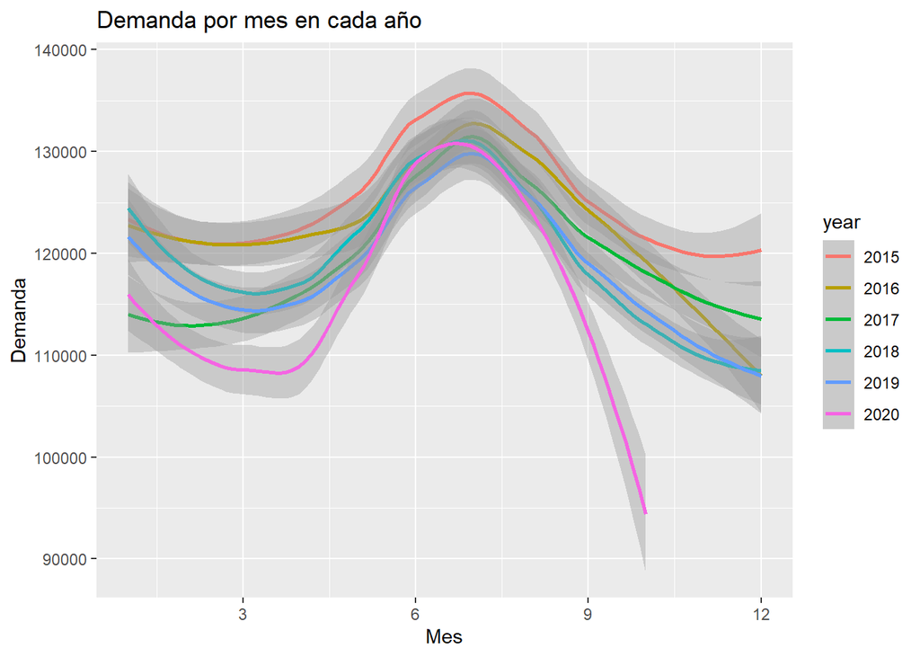

Y a continuación el promedio de la demanda agrupada por año (*year*). Podemos visualizar su tendencia levemente decreciente.

```
## # A tibble: 6 × 2
##   year  `Promedio Demand`
##   <fct>             <dbl>
## 1 2015            124662.
## 2 2016            121990.
## 3 2017            118953.
## 4 2018            118811.
## 5 2019            117940.
## 6 2020            117190.
```

Por otro lado si relacionamos demanda con día feriado y luego con día escolar, podemos observar una demanda sensiblemente mayor en días que no son feriados, y para el caso de día escolar si bien también es mayor relativamente lo es en menor medida.

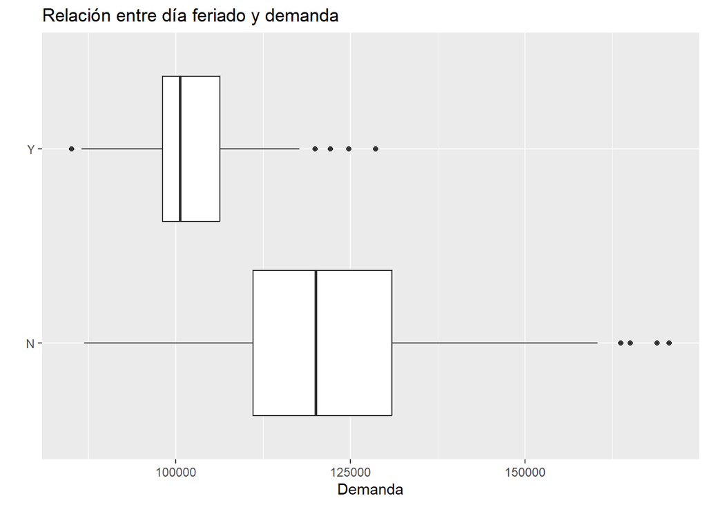

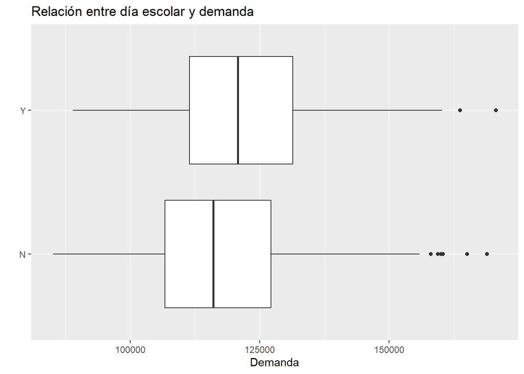

# Anexo

[output not shown]

[output cut: 2096 more lines]